# Recitation Week 9: Review

Eric R. Scott

```r
#libraries we'll need this week
library(ggplot2)
library(ggformula)
library(dplyr)
```

## Organizing Notebooks

At the bottom left of the notebook window there is a menu that shows the organization of the notebook. Add headings with different numbers of “#” and name code chunks using the gear icon in the code chunk.

```r
#shows up in the table of contents menu as "Chunk 1: the first code chunk"
```

Remember to type answers to questions *outside* of code chunks. This is useful for rounding R output or pointing out which piece of output is relevant.

## Resizing figures

You can also use the gear icon in the code chunks to change options indlucing using a custom figure size

```r
bees <- read.csv("BeeNectar.csv")
head(bees) #shows only the first 6 rows
```

|  | Colony | BeeID | Pollen | ITS | Nectar |
| --- | --- | --- | --- | --- | --- |
| 1 | 57 | B91 | 0.00000 | 4.03 | 0.00027 |
| 2 | 41 | 838E52010B000000 | 0.00153 | 2.87 | 0.00033 |
| 3 | 41 | 798C52010B000000 | 0.02089 | 3.19 | 0.00035 |
| 4 | 57 | B58 | 0.00034 | 3.07 | 0.00063 |
| 5 | 58 | G49 | 0.00000 | 3.42 | 0.00065 |
| 6 | 32 | R24 | 0.02855 | 3.86 | 0.00114 |

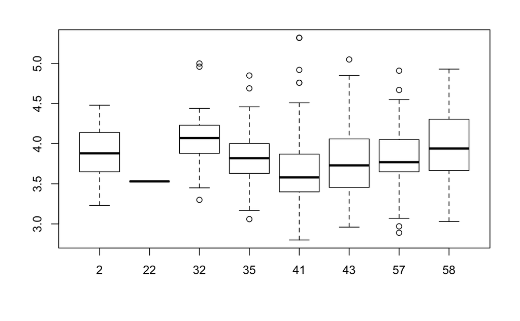

```r
boxplot(ITS ~ Colony, data = bees)
```

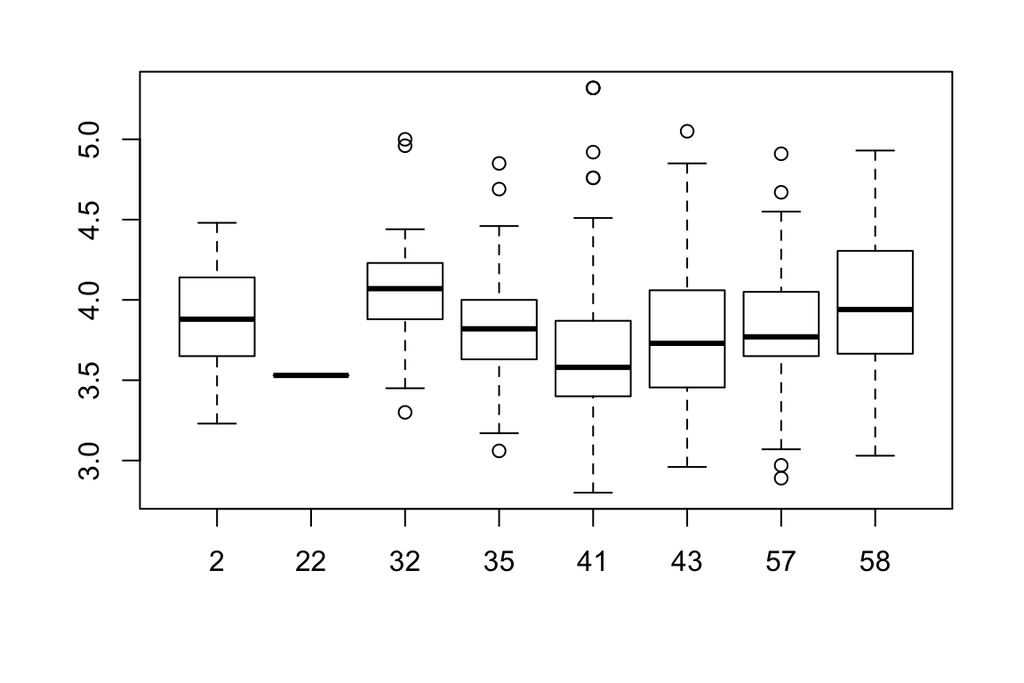

```r
boxplot(ITS ~ Colony, data = bees)
```

If you Knit this notebook to a Word document, you’ll see the results. Obviously the tiny figure is way too tiny! Use reasonable sizes, but feel free to re-size figures to save space and paper on your homeworks.

NOTE: base R graphics (e.g. `boxplot()`) have much larger margins than ggplot graphics for some reason. 2" x 3" seems like a reasonable size, but it actually comes out very squished looking because of the margins.

## Review

### Summary statistics / descriptive statistics

Summary or descriptive statistics are statistics that you calculate to summarise or describe your data. Mean, median, IQR, range, variance, standard deviation, etc. would all be called summary statistics or descriptive statistics.

```r
summary(bees)
```

```
     Colony          BeeID         Pollen              ITS           Nectar
 Min.   : 2.00   B67    :  7   Min.   :0.000000   Min.   :2.80   Min.   :0.00027
 1st Qu.:35.00   B24    :  6   1st Qu.:0.000000   1st Qu.:3.58   1st Qu.:0.01943
 Median :43.00   B58    :  5   Median :0.000000   Median :3.82   Median :0.03249
 Mean   :41.38   B64    :  5   Mean   :0.001994   Mean   :3.84   Mean   :0.03475
 3rd Qu.:57.00   B70    :  5   3rd Qu.:0.000000   3rd Qu.:4.07   3rd Qu.:0.04740
 Max.   :58.00   B73    :  5   Max.   :0.038210   Max.   :5.32   Max.   :0.13928
                 (Other):492                      NA's   :1
```

The `summary()` function is nice, but it only includes a set and limited number of summary statistics. It does however show us some useful things. One is that `Colony` is coded as a numeric variable. You can tell because it calculates statistics on it that don’t make any sense. The other is that ITS contains 1 NA. We’ll show how to deal with NAs later.

Let’s convert Colony to a factor before we do anything else.

```r
bees$Colony <- as.factor(bees$Colony) #replace the Colony column with a factor version
summary(bees)
```

```
     Colony        BeeID         Pollen              ITS           Nectar
 57     :169   B67    :  7   Min.   :0.000000   Min.   :2.80   Min.   :0.00027
 41     : 81   B24    :  6   1st Qu.:0.000000   1st Qu.:3.58   1st Qu.:0.01943
 43     : 68   B58    :  5   Median :0.000000   Median :3.82   Median :0.03249
 2      : 63   B64    :  5   Mean   :0.001994   Mean   :3.84   Mean   :0.03475
 35     : 62   B70    :  5   3rd Qu.:0.000000   3rd Qu.:4.07   3rd Qu.:0.04740
 32     : 45   B73    :  5   Max.   :0.038210   Max.   :5.32   Max.   :0.13928
 (Other): 37   (Other):492                      NA's   :1
```

Let’s make our own summary table with the `summarize()` function in `dplyr`.

```r
library(dplyr)
bees %>%
  group_by(Colony) %>%
  summarise(mean.ITS = mean(ITS),
            median.ITS = median(ITS),
            SEM.ITS = sd(ITS)/sqrt(n()),
            sample.size = n())
```

| Colony | mean.ITS | median.ITS | SEM.ITS | sample.size |
| --- | --- | --- | --- | --- |
| 2 | NA | NA | NA | 63 |
| 22 | 3.530000 | 3.53 | NA | 1 |
| 32 | 4.078667 | 4.07 | 0.04628807 | 45 |
| 35 | 3.846290 | 3.82 | 0.04113940 | 62 |
| 41 | 3.708642 | 3.58 | 0.05863540 | 81 |
| 43 | 3.775588 | 3.73 | 0.05328184 | 68 |
| 57 | 3.821243 | 3.77 | 0.02767847 | 169 |
| 58 | 3.950278 | 3.94 | 0.07303781 | 36 |

```r
#same thing as:
#summarise(group_by(bees, Colony), mean.ITS = mean(ITS)....)
```

The pipe `%>%` can be read as “and then…”. Functionally it takes whatever is on the left and puts it in the first argument slot of whatever function is on the right. So `bees %>% group_by(Colony)` is exactly the same as `group_by(bees, Colony)`. Using the pipe allows for more readable code without so many nested functions.

`group_by()` allows you to apply functions *by group*, in this case, by Colony. It’s effects on a data frame are invisible

```r
bees %>% group_by(Colony)
```

| Colony | BeeID | Pollen | ITS | Nectar |
| --- | --- | --- | --- | --- |
| 57 | B91 | 0.00000 | 4.03 | 0.00027 |
| 41 | 838E52010B000000 | 0.00153 | 2.87 | 0.00033 |
| 41 | 798C52010B000000 | 0.02089 | 3.19 | 0.00035 |
| 57 | B58 | 0.00034 | 3.07 | 0.00063 |
| 58 | G49 | 0.00000 | 3.42 | 0.00065 |
| 32 | R24 | 0.02855 | 3.86 | 0.00114 |
| 58 | G31 | 0.00000 | 4.34 | 0.00132 |
| 57 | B59 | 0.00000 | 3.61 | 0.00155 |
| 57 | B53 | 0.00000 | 3.71 | 0.00196 |
| 57 | B79 | 0.00000 | 4.01 | 0.00246 |

[output cut: 515 more lines]

```r
#this looks exactly the same as the original bees data, but there is some hidden information about which column is the grouping variable
```

`n()` doesn’t take any arguments because it is looking at the sample size of the groups. It only works within a dplyr “pipeline” (you could use `length()` to do a similar thing outside of a `summarise()` function).

#### What summary statistics should I calculate?

When we say “calculate summary statistics to test the assumptions of the test” you should calculate whatever statistics you think necessary to justify using or not using a particular statistical test. So if your test assumes homogeneity of variances, calculate a variance for each group. If your test assumes normality, you could check the mean and median to see if the data are skewed (note: this is **NOT** the only way data can be non-normal). Let’s check variances of the ITS data:

```r
bees %>% group_by(Colony) %>%
  summarise(ITSvar = var(ITS))
```

| Colony | ITSvar |
| --- | --- |
| 2 | NA |
| 22 | NA |
| 32 | 0.09641636 |
| 35 | 0.10493191 |
| 41 | 0.27848688 |
| 43 | 0.19304890 |
| 57 | 0.12947047 |
| 58 | 0.19204278 |

Colony 2 and colony 22 don’t have variances associated with them. Why might that be? What other summary statistics could you calculate to help figure this out?

One reason `var()` might return `NA` is if the data contains some `NA`s. We can use the `anyNA()` function for that. Another reason might be that there is only 1 value—you can’t calculate a variance on only one number! Let’s check for that using `n()` which gives you the number of observations in each group. Because `n()` acts on the group, not on ITS, you don’t give it any arguments.

```r
bees %>% group_by(Colony) %>%
  summarise(ITSvar = var(ITS),
            NAs = anyNA(ITS),   # returns "TRUE" if there is an NA in any observation.
            samplesize = n())
```

| Colony | ITSvar | NAs | samplesize |
| --- | --- | --- | --- |
| 2 | NA | TRUE | 63 |
| 22 | NA | FALSE | 1 |
| 32 | 0.09641636 | FALSE | 45 |
| 35 | 0.10493191 | FALSE | 62 |
| 41 | 0.27848688 | FALSE | 81 |
| 43 | 0.19304890 | FALSE | 68 |
| 57 | 0.12947047 | FALSE | 169 |
| 58 | 0.19204278 | FALSE | 36 |

Ah, remember that colony 22 only has one observation. Let’s remove it.

```r
bees <- subset(bees, Colony != "22")
#subset "bees" taking all the rows where "Colony" isn't "22".  Overwrite "bees"
```

#### Dealing with NAs

You can deal with NAs in a couple of ways. One is to tell a function to ignore them. Many functions have the optional argument `na.rm =`. If you set this to `TRUE` it will remove any NAs before doing its calculations

```r
bees %>% group_by(Colony) %>%
  summarise(ITSvar = var(ITS, na.rm = TRUE),
            ITS.NAs = anyNA(ITS),
            samplesize = n())
```

| Colony | ITSvar | ITS.NAs | samplesize |
| --- | --- | --- | --- |
| 2 | 0.10208228 | TRUE | 63 |
| 32 | 0.09641636 | FALSE | 45 |
| 35 | 0.10493191 | FALSE | 62 |
| 41 | 0.27848688 | FALSE | 81 |
| 43 | 0.19304890 | FALSE | 68 |
| 57 | 0.12947047 | FALSE | 169 |
| 58 | 0.19204278 | FALSE | 36 |

You could also remove any rows containing NAs, but that doesn’t make sense here because the NA is only in ITS, not Nectar or Pollen

```r
bees %>% group_by(Colony) %>%
  summarise(ITSNA = anyNA(ITS),
            nectarNA = anyNA(Nectar),
            pollenNA = anyNA(Pollen))
```

| Colony | ITSNA | nectarNA | pollenNA |
| --- | --- | --- | --- |
| 2 | TRUE | FALSE | FALSE |
| 32 | FALSE | FALSE | FALSE |
| 35 | FALSE | FALSE | FALSE |
| 41 | FALSE | FALSE | FALSE |
| 43 | FALSE | FALSE | FALSE |
| 57 | FALSE | FALSE | FALSE |
| 58 | FALSE | FALSE | FALSE |

```r
#if you wanted to remove the row with the NA
# bees2 <- subset(bees, !is.na(ITS))
```

### Plotting

So far we’ve learned to make boxplots, histograms, barplots, paired data plots, and Q–Q plots. Let’s review a few of those.

#### boxplots

Using the `boxplot()` function, boxplots are very easy and take a formula, just like `leveneTest()`, `aov()`, and many other functions.

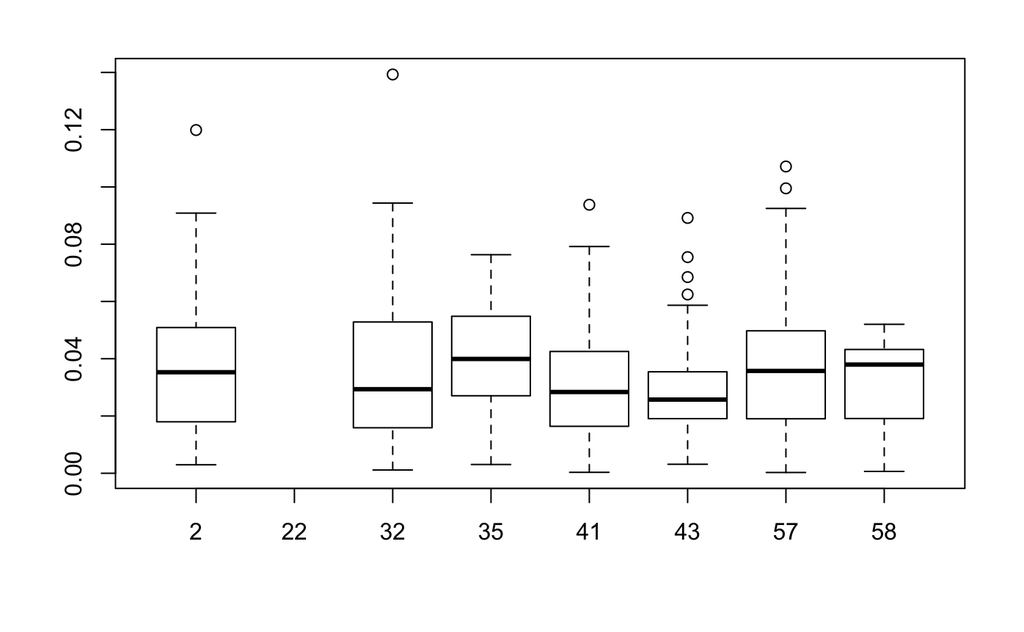

```r
boxplot(Nectar ~ Colony, data = bees)
```

A “formula” in R isn’t a mathematical formula, but a way of coding your data. In this case you could read `Nectar ~ Colony` as “Nectar loads explained by Colony differences”.

Notice that colony 22 still shows up. This is because we removed it from the data set, but haven’t removed the “level” from the factor “Colony”. R still thinks 22 is a valid level and plots it.

```r
levels(bees$Colony) # returns the possible levels of a factor
```

```
[1] "2"  "22" "32" "35" "41" "43" "57" "58"
```

**How might you fix this?** - remove colony 22 *before* converting `Colony` to a factor - `boxplot()` has an optional `drop = TRUE` argument which drops factor levels with no observations

You can also make boxplots with `ggplot2` which will drop any missing levels by default.

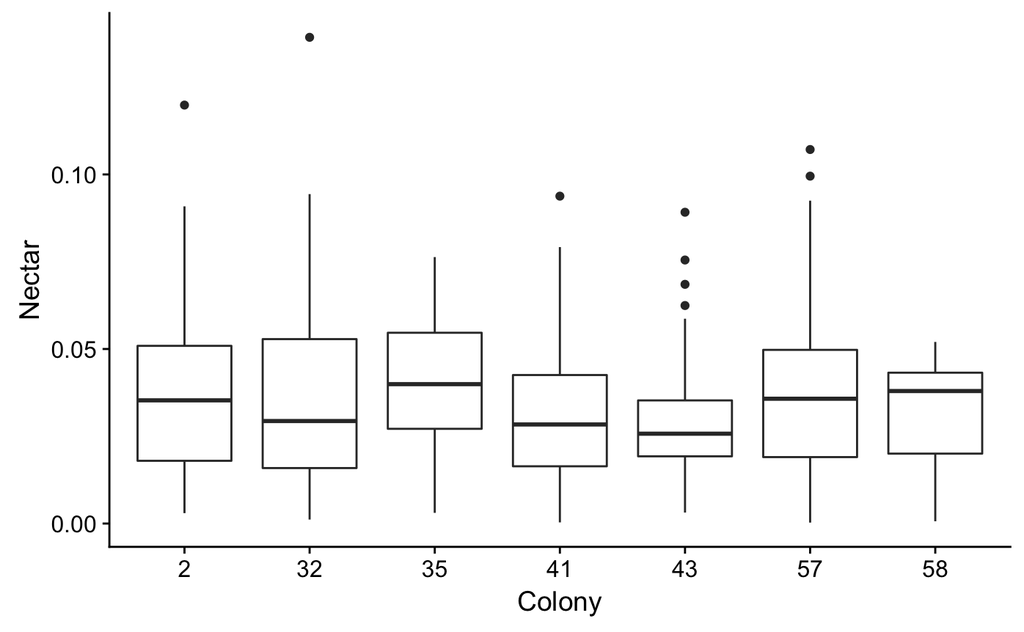

```r
ggplot(bees, aes(x = Colony, y = Nectar)) + #fails if you didn't convert Colony to a factor.
  geom_boxplot()
```

#### Histograms

Histograms show the shape of the distribution of your data (or residuals). We started off using the base R function `hist()`, but this function is often frustrating because it doesn’t easily let you specify the number of bins you want. Let’s review how to do histograms in ggplot2

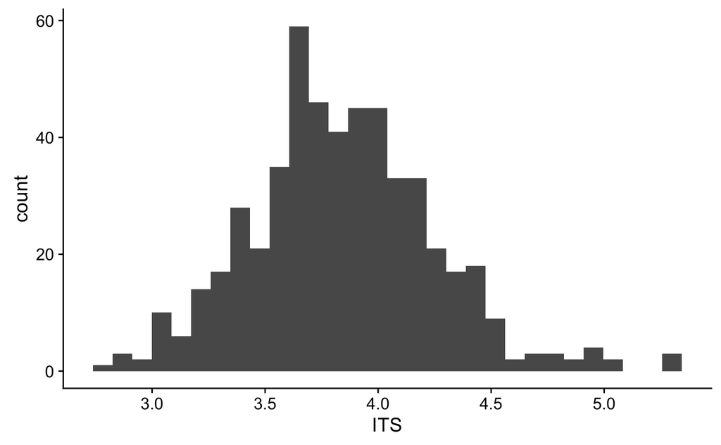

```r
ggplot(bees, aes(x = ITS)) +
  geom_histogram()
```

You’ll notice that if we run this without giving `geom_hist()` a `bins =` argument, it warns us that the default, 30 bins, is probably not good. In this case, it also warns us that it removed our NA in order to draw the histogram. Let’s choose a reasonable number of bins

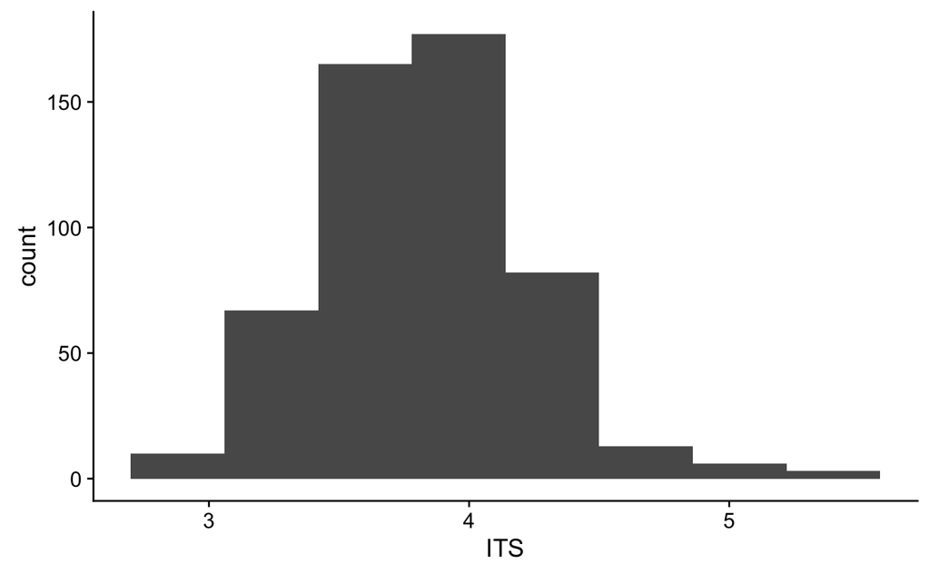

```r
ggplot(bees, aes(x = ITS)) +
  geom_histogram(bins = 8)
```

If we wanted to see a separate histogram for every colony, we could add `facet_wrap("Colony")`. This works for pretty much any type of plot made by ggplot. By default, it uses the same axes and number of bins for every histogram, which is what we want!

```r
ggplot(bees, aes(x = ITS)) +
  geom_histogram(bins = 8) +
  facet_wrap("Colony")
```

[output not shown]

Note that you probably wouldn’t actually want to do this with so many groups. A boxplot is a better way to summarize the data and doing a histogram on the *residuals* is a better way of checking assumptions of normality.

#### Bar Plots

Bar plots don’t show as much information as boxplots, but are sometimes useful for showing differences between means, and allow plotting of error bars that represent various things (standard devation, SEM, 95% confidence intervals) Bar plots need summarized data, because the only information they need is the group variable and the means for each group.

```r
#remember the na.rm = TRUE!!
bees.summary <- bees %>% group_by(Colony) %>%
  summarise(mean.ITS = mean(ITS, na.rm = TRUE), SEM.ITS = sd(ITS, na.rm = TRUE)/sqrt(n()))
bees.summary
```

| Colony | mean.ITS | SEM.ITS |
| --- | --- | --- |
| 2 | 3.896452 | 0.04025362 |
| 32 | 4.078667 | 0.04628807 |
| 35 | 3.846290 | 0.04113940 |
| 41 | 3.708642 | 0.05863540 |
| 43 | 3.775588 | 0.05328184 |
| 57 | 3.821243 | 0.02767847 |
| 58 | 3.950278 | 0.07303781 |

Previously, we learned to make bar plots with `barplot()`, but now that you know the basics of ggplot, I think you’ll find the ggplot way easier. There are two geoms that make bar plots. `geom_col()` works on already summarized data. `geom_bar()` actually works kind of like a histogram, and will plot counts. This is NOT what you want. Use `geom_col()`!

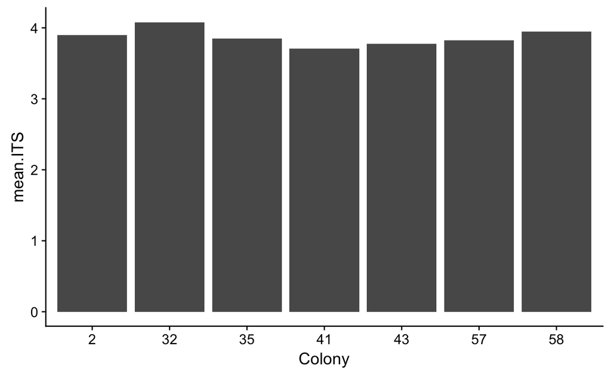

```r
ggplot(bees.summary, aes(x = Colony, y = mean.ITS)) +
  geom_col()
```

We can add error bars with a geom!

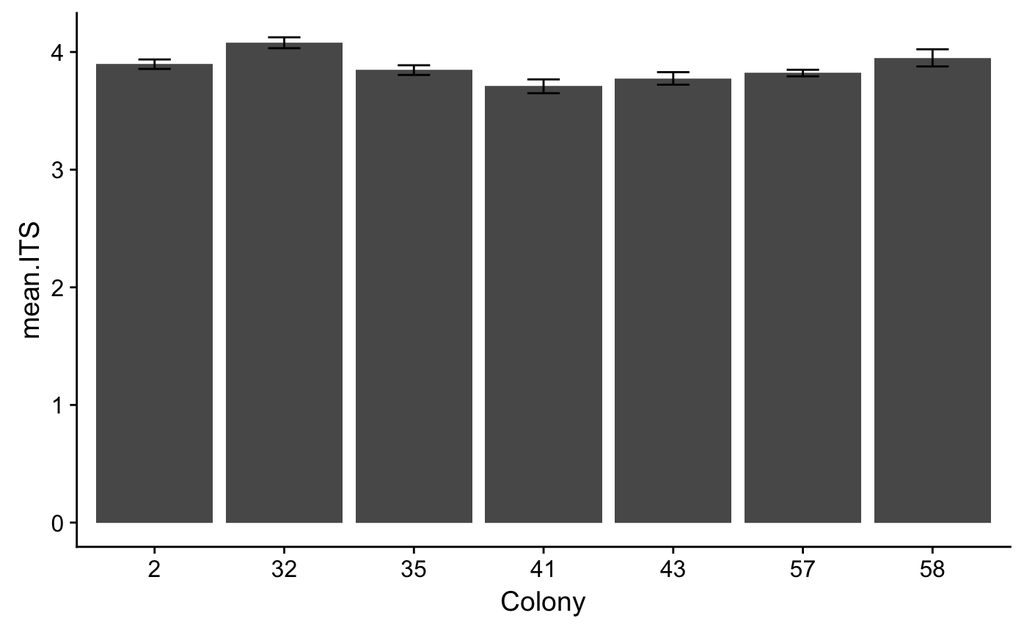

```r
ggplot(bees.summary, aes(x = Colony, y = mean.ITS)) +
  geom_col() +
  geom_errorbar(aes(ymin = mean.ITS - SEM.ITS,
                    ymax = mean.ITS + SEM.ITS),
                width = 0.25)
```

```r
#by default, the errorbars are as wide as the bars.  width = 0.25 changes them to about a quarter the width of the bars
```

### ANOVA

I know we just went through ANOVA last week, but here’s a quick review. To do an ANOVA, first you set up the ANOVA model with `aov()`

```r
#uses same formula interface as boxplot and leveneTest.  Can be read as "ITS as explained by Colony differences"
ITS.aov <- aov(ITS ~ Colony, data = bees)
ITS.aov
```

```
Call:
   aov(formula = ITS ~ Colony, data = bees)

Terms:
                  Colony Residuals
Sum of Squares   4.94003  80.55595
Deg. of Freedom        6       516

Residual standard error: 0.3951154
Estimated effects may be unbalanced
1 observation deleted due to missingness
```

`aov()` calculates sums of squares, but doesn’t calculate an F statistic or a p-value. This aov object contains several things including the residuals, which we need for testing assumptions of normality. You can extract them with the $ operator

```r
head(ITS.aov$residuals) #only shows the first 6 values
```

```
         1          2          3          4          5          6
 0.2087574 -0.8386420 -0.5186420 -0.7512426 -0.5302778 -0.2186667
```

You can do some things directly with these residuals in this format, like the shapiro-wilks test

```r
shapiro.test(ITS.aov$residuals)
```

```
    Shapiro-Wilk normality test

data:  ITS.aov$residuals
W = 0.97502, p-value = 8.737e-08
```

But `ggplot()` requires a data frame, not a vector. To create a data frame, we can use `data.frame()`. Inside of `data.frame()` you can create columns by chosing a name for them and assigning something to them

```r
data.frame(x = c(1,2,3), y = c("a", "b", "c"))
```

| x | y |
| --- | --- |
| 1 | a |
| 2 | b |
| 3 | c |

Let’s create a data frame with our residuals

```r
ITS.resids <- data.frame(residuals = ITS.aov$residuals)
ITS.resids
```

|  | residuals |
| --- | --- |
| 1 | 0.208757396 |
| 2 | -0.838641975 |
| 3 | -0.518641975 |
| 4 | -0.751242604 |
| 5 | -0.530277778 |
| 6 | -0.218666667 |
| 7 | 0.389722222 |
| 8 | -0.211242604 |
| 9 | -0.111242604 |
| 10 | 0.188757396 |

[output cut: 513 more lines]

Now lets do some plotting with it

Histogram:

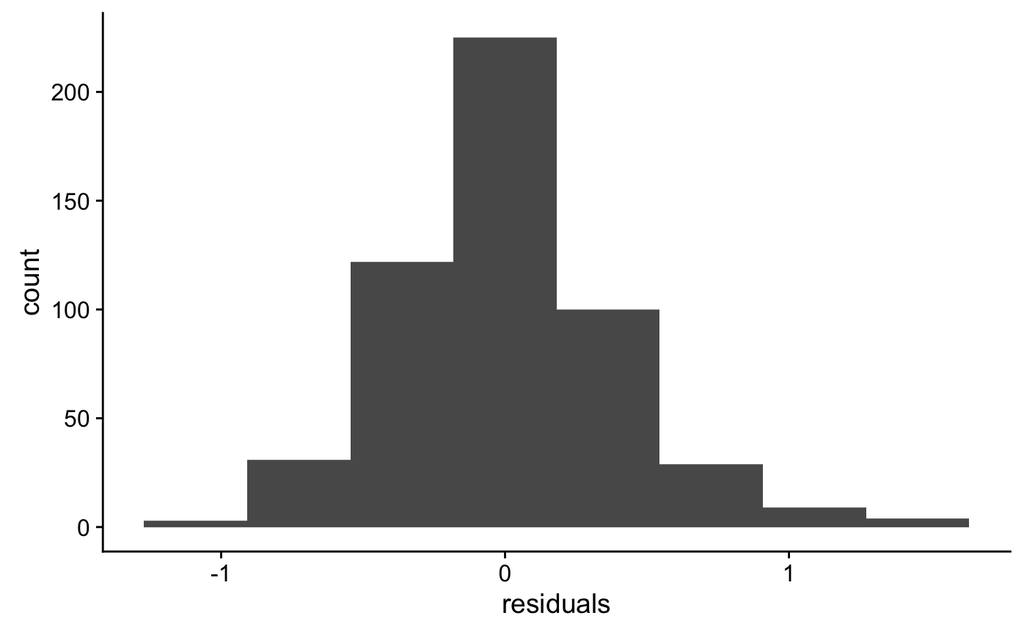

```r
ggplot(ITS.resids, aes(residuals)) +
  geom_histogram(bins = 8)
```

Q–Q plot:

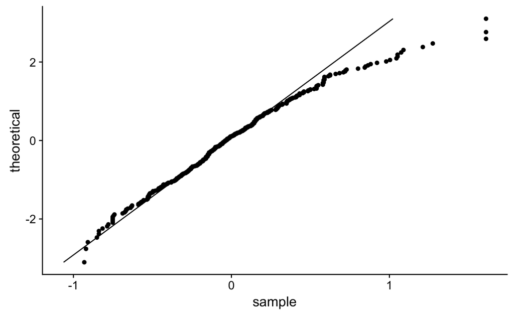

```r
ggplot(ITS.resids, aes(sample = residuals)) +
  geom_qq() +
  stat_qqline() + #from ggformula package
  coord_flip() #this just makes the sample data on the x-axis so it is like the textbook and slides.
```

To get the ANOVA table, including a p-value, use `anova()` on the object we created with `aov()`

```r
anova(ITS.aov)
```

```
Analysis of Variance Table

Response: ITS
           Df Sum Sq Mean Sq F value    Pr(>F)
Colony      6  4.940 0.82334  5.2739 2.732e-05 ***
Residuals 516 80.556 0.15612
---
Signif. codes:  0 ‘***’ 0.001 ‘**’ 0.01 ‘*’ 0.05 ‘.’ 0.1 ‘ ’ 1
```

Note: the data **definitely** did **not** meet the assumptions of ANOVA, so this is **not** a good idea

If you wanted to do a non-parametric Kruskal-Wallis test instead, you set it up in a similar way to `aov()`

```r
kruskal.test(ITS ~ Colony, data = bees)
```

```
    Kruskal-Wallis rank sum test

data:  ITS by Colony
Kruskal-Wallis chi-squared = 42.782, df = 6, p-value = 1.288e-07
```

Chi-squared is the test statistic.